# Inference from a mediator

Macartan

April 27, 2019

# 1 A model with possible confounding

We explore a model where a front door type criterion is satisfied. Causal relations are given by $X\rightarrow M \rightarrow Y$. However there is confounding: $X$ is less likely in cases where $Y=1$.

In this setting, because of confounding, we greatly underestimate the effect of $X$ on $Y$ with simple $X,Y$ data; with full data on $M$ we do very well; but we also do well even with quite partial data on $M$, e.g. for 50 out of 50,000 cases.

```r
model <-
    make_model("X -> M -> Y") %>%
    set_parameter_matrix(confound = list(c(X="X"), list( Y = "11" )))%>%
    set_priors()
```

Graph it:

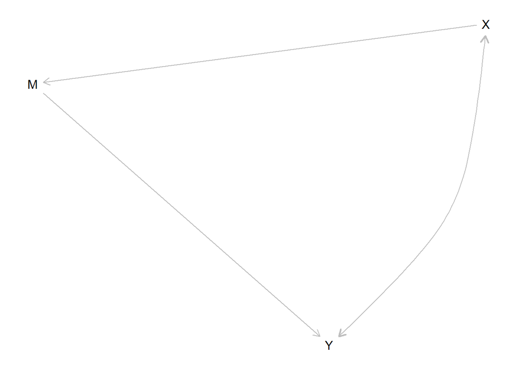

```r
plot_dag(model)
```

# 2 Draw data

We imagine a true model with a treatment effect of .25 but negative confounding.

```r
# true lambda
true_lambda = c(.8, .2, .5, .5, .25, .5, 0, .25, .25, .5, 0, .25)
```

Generate three data frames: full XMY data, XY data only, XY and small M data

```r
n <- 50000

data       <- dataXY <- data_partial <- simulate_data(model, n = n, lambda = true_lambda)
dataXY$M   <- NA
data_partial$M[sample(1:n, n - 50)] <- NA
```

# 3 Naive analysis

A naive analysis might regress $Y$ on $X$.

```r
with(data, lm(Y~X)$coef)
```

```
## (Intercept)           X
##   0.4551943   0.1060485
```

Note that the the estimated ATE is too low – about half of what it should be.

# 4 Bayes analysis

Instead we will directly calculate posteriors on admissible causal types.

```r
# Full Data
updated_full     <- gbiqq(model, data)

# X, Y data only
updated_XY       <- gbiqq(model, dataXY)

# Partial Data
updated_partial  <- gbiqq(model, data_partial)
```

# 5 Illustrate joint posteriors

Here are graphs of posteriors over the effect of $X$ on $Y$.

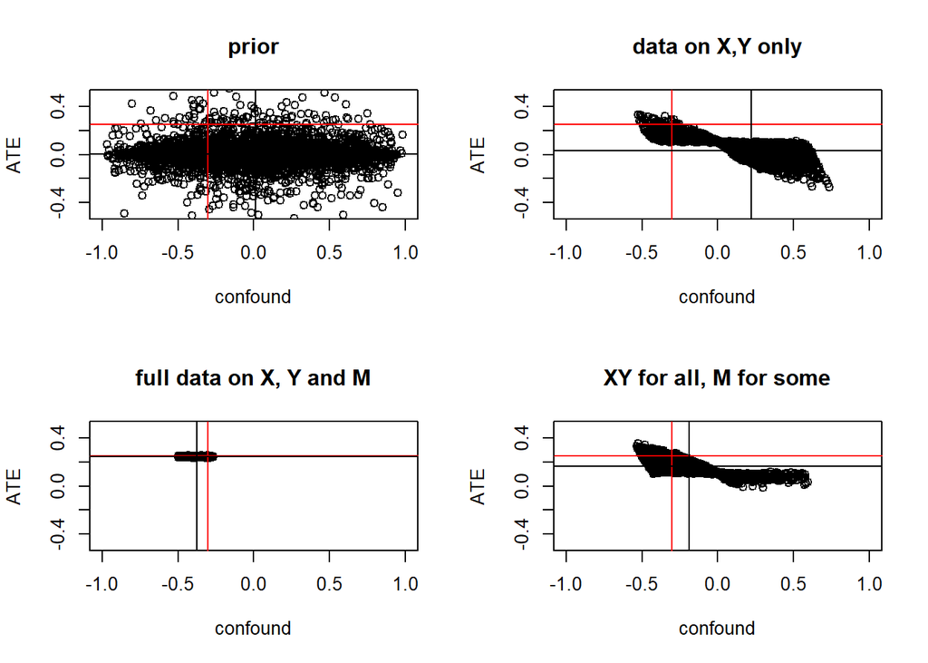

The prior plot shows where the true values lie relative to the prior distribution. There is an expectation of no confounding despite significant negative confounding. The true effect is positive though there is a prior expectation of no effect.

- Data on XY alone produces a posterior with a strong negative correlation between beliefs about effects and beliefs over confounding. Posterior means for both causal effects and confounding are far off.
- We see that with full data we estimate the ATE correctly. Here the front door criterion provides identification. Our estimate of the confound is nevertheless incorrect due to the fact that the confounding is not identified by this model. Its admissible range is however greatly circumscribed.
- With partial data we end up between these extreme with a large reduction in bias despite relative few cases with data on the mediator.